# Wine Quality Analysis

[figure not shown]

[figure not shown]

[figure not shown]

[figure not shown]

[figure not shown]

[figure not shown]

[figure not shown]

[figure not shown]

[figure not shown]

[figure not shown]

[figure not shown]

[figure not shown]

[3 more figures not shown]

# Basic Information

*Analysis of Factors on Wine Quality*

### Introduction

The purpose of this study is to look at the question: Can the quality score of a wine be determined by its chemical makeup? Here is a glimpse of the data:

```
'data.frame':   6497 obs. of  13 variables:
 $ fixed.acidity       : num  7.4 7.8 7.8 11.2 7.4 7.4 7.9 7.3 7.8 7.5 ...
 $ volatile.acidity    : num  0.7 0.88 0.76 0.28 0.7 0.66 0.6 0.65 0.58 0.5 ...
 $ citric.acid         : num  0 0 0.04 0.56 0 0 0.06 0 0.02 0.36 ...
 $ residual.sugar      : num  1.9 2.6 2.3 1.9 1.9 1.8 1.6 1.2 2 6.1 ...
 $ chlorides           : num  0.076 0.098 0.092 0.075 0.076 0.075 0.069 0.065 0.073 0.071 ...
 $ free.sulfur.dioxide : num  11 25 15 17 11 13 15 15 9 17 ...
 $ total.sulfur.dioxide: num  34 67 54 60 34 40 59 21 18 102 ...
 $ density             : num  0.998 0.997 0.997 0.998 0.998 ...
 $ pH                  : num  3.51 3.2 3.26 3.16 3.51 3.51 3.3 3.39 3.36 3.35 ...
 $ sulphates           : num  0.56 0.68 0.65 0.58 0.56 0.56 0.46 0.47 0.57 0.8 ...
 $ alcohol             : num  9.4 9.8 9.8 9.8 9.4 9.4 9.4 10 9.5 10.5 ...
 $ quality             : int  5 5 5 6 5 5 5 7 7 5 ...
 $ wine_type           : chr  "Red" "Red" "Red" "Red" ...
```

## Column ( data-width= 400)

### Variable Introduction

Fixed Acidity: This refers to the non-volatile acids that do not evaporate readily. A higher fixed acidity typically gives wine a more tart taste. It’s an essential component for the structure and body of the wine. (continuous)

Volatile Acidity: Represents the amount of acetic acid in wine, which at too high of a level can lead to an unpleasant vinegar taste. It’s a key indicator of wine spoilage. (continuous)

Citric Acid: Found in small quantities in wine, it’s one of the fixed acids that can add freshness and flavor to wines. (continuous)

Residual Sugar: This is the sugar remaining after fermentation stops, affecting the sweetness of the wine. Wines can range from bone-dry to very sweet, depending on the residual sugar level. (continuous)

Chlorides: The amount of salt in the wine. High levels can lead to a salty taste, which is generally not desired in higher-quality wines. (continuous)

Free Sulfur Dioxide: The portion of sulfur dioxide that is not bound to other molecules; sulfur dioxide is used as a preservative to prevent spoilage and oxidation in wine. (continuous)

Total Sulfur Dioxide: This includes both free and bound sulfur dioxide. It’s related to wine longevity and can influence the wine’s aroma and flavor. (continuous)

Density: It’s related to the alcohol and sugar content of the wine. Wines with higher alcohol content will typically have a lower density-Possibly collinearity (continuous)

pH: Indicates the acidity of the wine on a scale from 0 (very acidic) to 14 (very basic); most wines are between 3 and 4 on the pH scale. The pH affects flavor, color, and stability. (continuous)

Sulphates: These are compounds that can influence the fermentation process and act as antioxidants and preservatives. They may also affect the aroma and flavor profile of the wine. (continuous)

Alcohol: The alcohol content in wine, which results from the fermentation of sugars. Alcohol can influence the body, flavor, and overall balance of the wine. (continuous)

Wine_type: Red or white wine indicates the type of grape used (categorical)

Quality- Quality score from 1-10 (integer) (This is the target variable)

# Explanatory Data Analysis 1

## Column (data-width= 00)

### Correlation

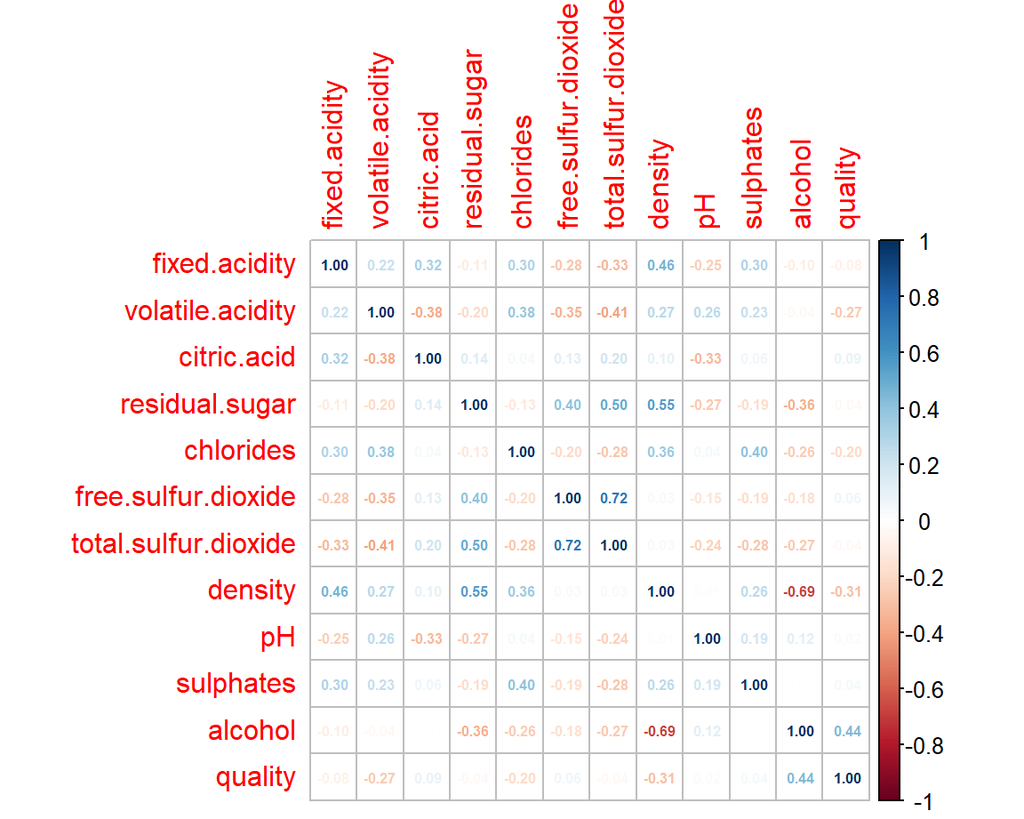

## Column (data-width=400)

### Summary

When looking at the correlation table. Alcohol has the highest of any of the explanatory variables with quality. Then it is followed with density. However alcohol and density are highly correlated so there may be evidence of co linearity here. It also, appears that volatile acidity and chlorides both have a negative relationship with quality. Due to the possible presence of co linearity and variable having a low impact on quality we will likely move forward with the Lasso model selection.

# Explanatory Data Analysis 2

### Fixed Acidity

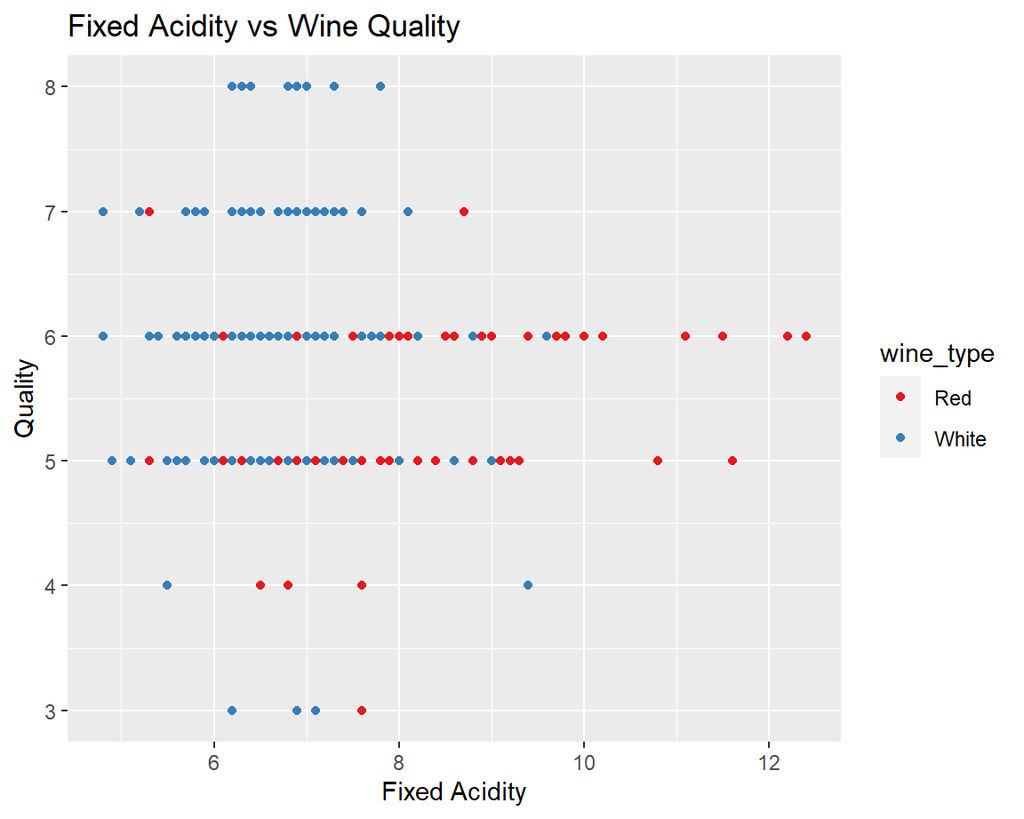

### Volatile Acidity

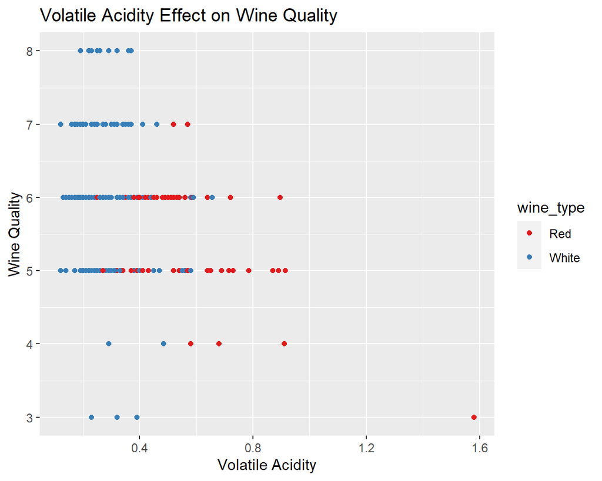

### Citric Acid

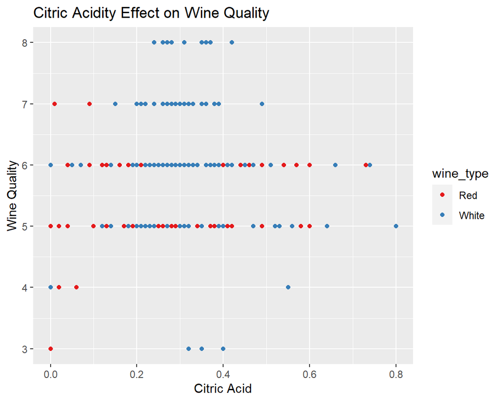

### Chlorides

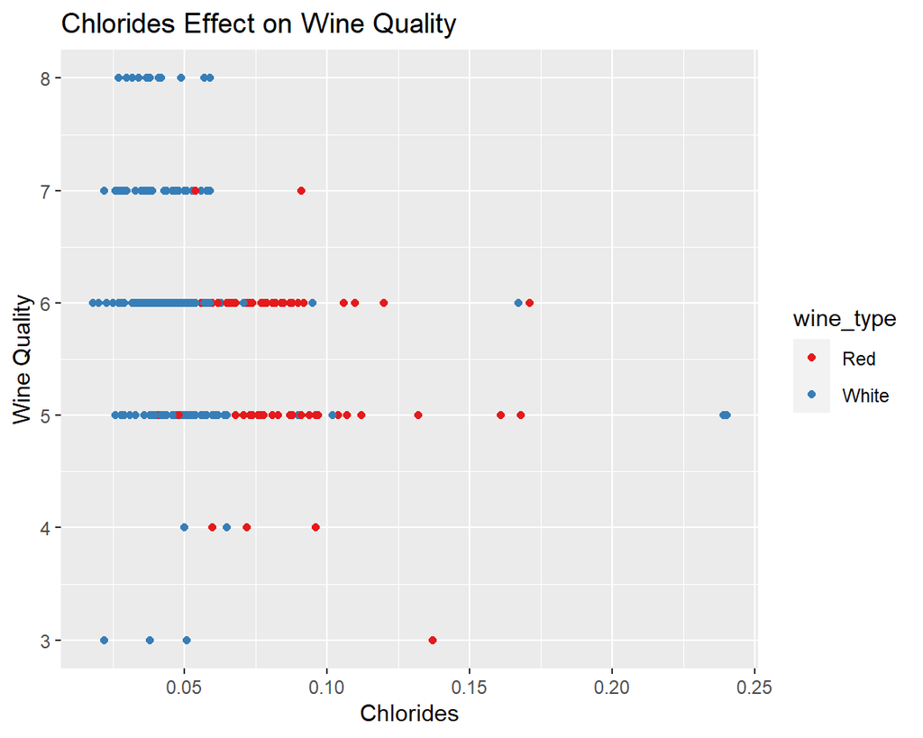

### Free Sulfur Dioxide

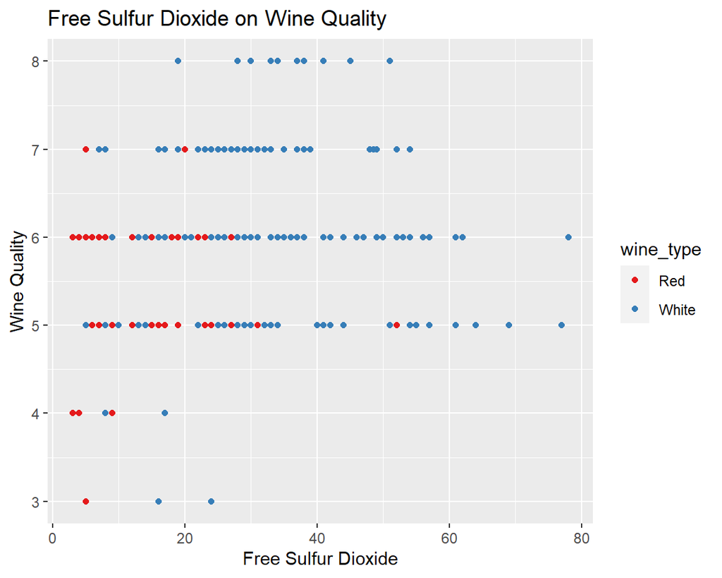

### Total Sulfur Dioxide

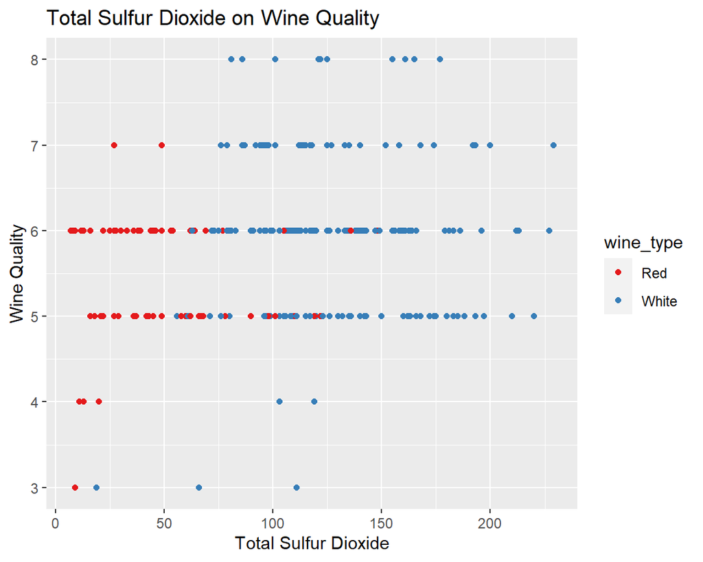

### Density

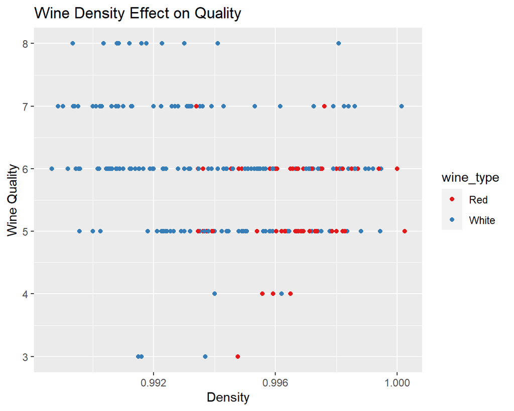

### pH

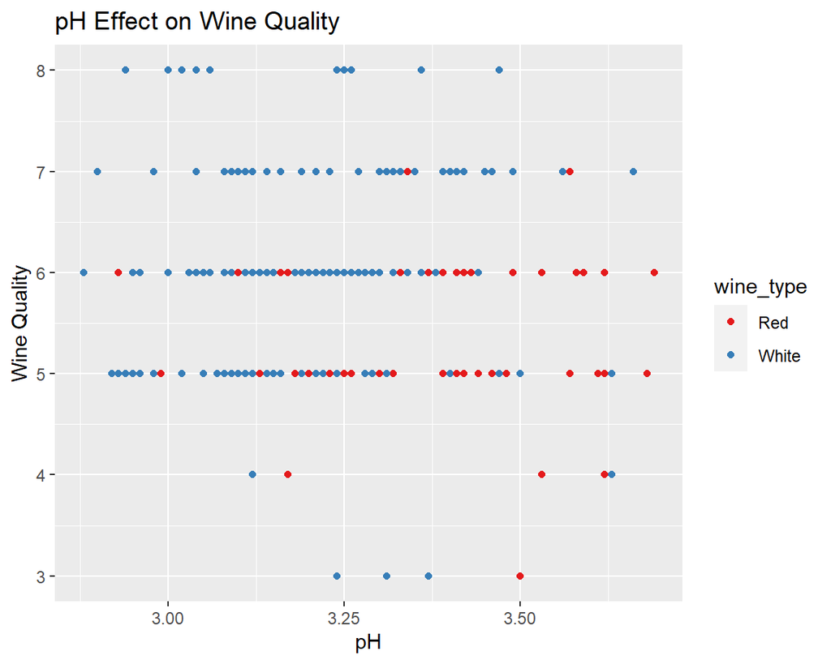

### Sulphates

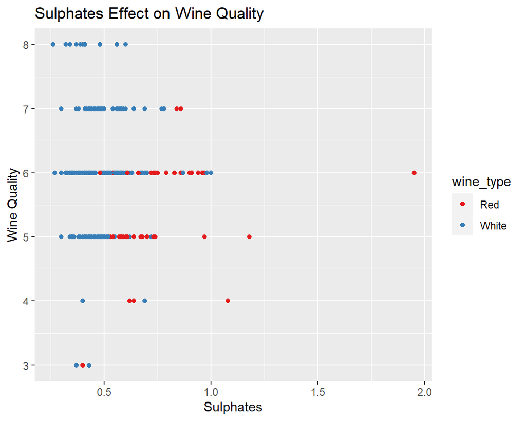

### Alcohol

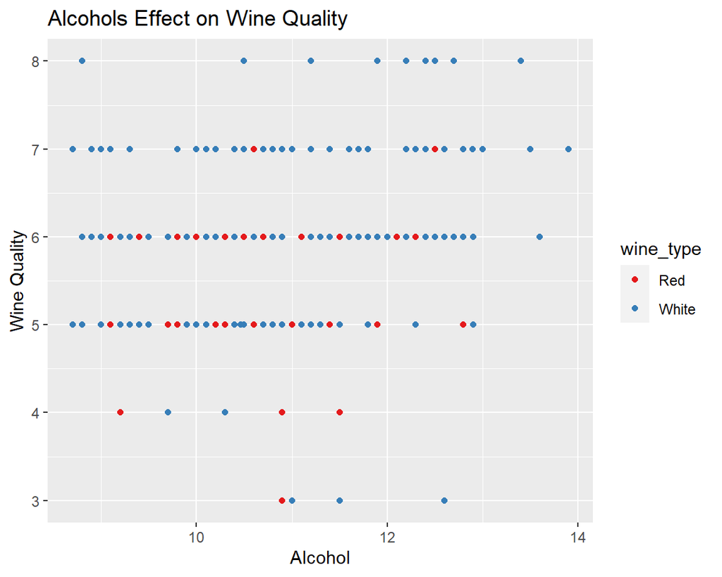

## Column (data-width= 400)

### Summary

Looking through these plots you can tell that there does not seem to be the strongest correlation and patterns in the relationship between these variables and quality. I think this can be because quality is so subject it is hard to place. Also, from looking through these plots it does not seem red or white wine has much of an impact on the quality score given. It may be better to predict classification of red and white wine instead of quality in this example.

# Model Selection

### Lasso

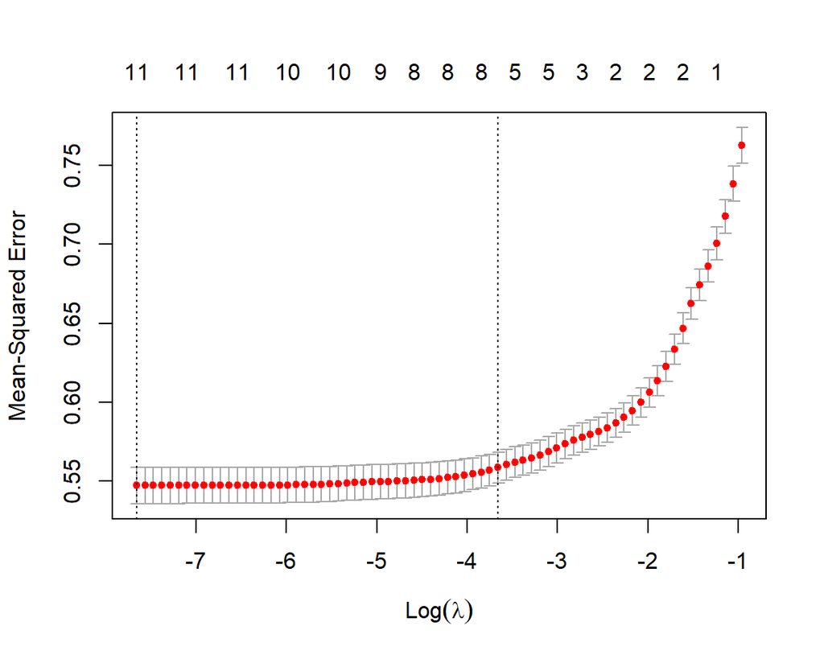

### Coefficients

```
13 x 1 sparse Matrix of class "dgCMatrix"
                                s0
(Intercept)           56.089681112
fixed.acidity          0.062429038
volatile.acidity      -1.309900964
citric.acid           -0.025693287
residual.sugar         0.043638700
chlorides             -0.450803635
free.sulfur.dioxide    0.006080485
total.sulfur.dioxide  -0.002536577
density              -55.327493280
pH                     0.460149064
sulphates              0.735986849
alcohol                0.265305200
wine_type              .
```

## Column (data-width= 400)

### Reasoning

After many different models I landed on trying to do the Lasso regression to try and combat the co linearity. First the R^2 for the training data was 0.2767 and for the test data was 0.2916. The linear model did not appear to get a high R^2 and transformation did not help with the R^2 either. I think this is because the quality data is an integer that is also really subjected so a linear model may not be accurate for prediction.

We will pick the lambda with the smallest average SSE based on cross validation.

Instead, I will try and predict if wine is of good or bad quality with logistic regression which may have a better effect.

# Model Assumptions

### Normality

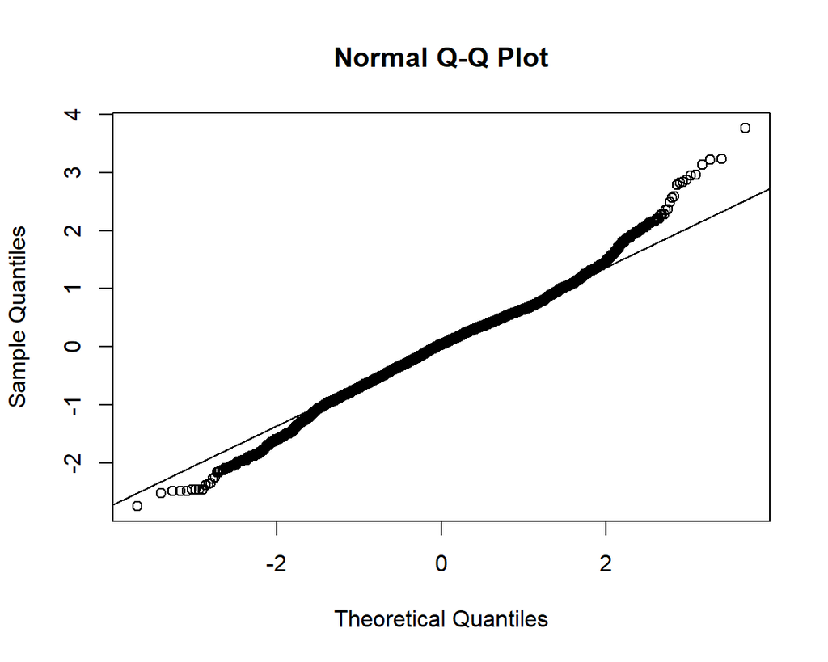

### AD Test

```
    Anderson-Darling normality test

data:  y_predicted - y.train
A = 9.2475, p-value < 2.2e-16
```

### Variance

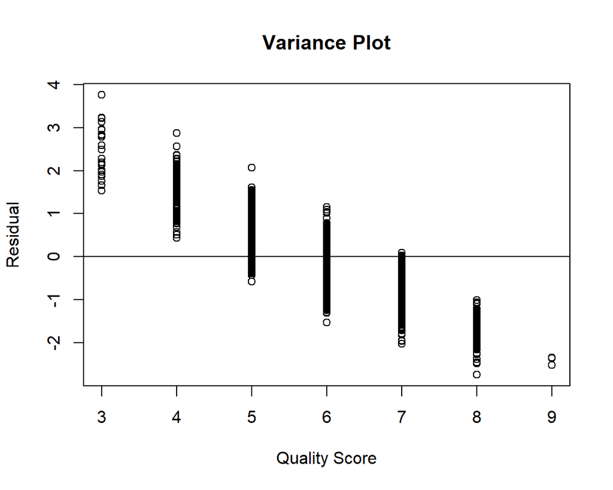

## Column (data-width= 400)

### Explanation

It seems to not follow the normality assumption very well and based on the Anderson darling test this assumption is not met. However there is not a constant variance. There seems to be a pattern throughout the variance that violates this assumption. I have tried transformations and looked at outliers which did not effect this variance. Instead due to the low r squared and the lack of these conditions being met we will try and use wine type and see if we can solve the other research question.

# Revised Model

### Logistic Base

```
Call:
glm(formula = quality_binary ~ . - quality, family = "binomial",
    data = train_data)

Deviance Residuals:
    Min       1Q   Median       3Q      Max
-2.7532  -0.8949   0.4277   0.8012   2.6482

Coefficients:
                       Estimate Std. Error z value Pr(>|z|)
(Intercept)           1.252e+02  5.129e+01   2.441  0.01464 *
fixed.acidity         9.989e-02  5.910e-02   1.690  0.09102 .
volatile.acidity     -4.846e+00  3.510e-01 -13.808  < 2e-16 ***
citric.acid          -2.869e-01  3.040e-01  -0.944  0.34518
residual.sugar        1.213e-01  2.222e-02   5.458 4.82e-08 ***
chlorides            -7.078e-01  1.213e+00  -0.583  0.55971
free.sulfur.dioxide   1.352e-02  3.040e-03   4.448 8.66e-06 ***
total.sulfur.dioxide -5.374e-03  1.262e-03  -4.258 2.06e-05 ***
density              -1.375e+02  5.206e+01  -2.641  0.00827 **
pH                    1.085e+00  3.538e-01   3.065  0.00217 **
sulphates             2.285e+00  3.220e-01   7.097 1.27e-12 ***
alcohol               8.268e-01  6.953e-02  11.891  < 2e-16 ***
wine_typeWhite       -5.931e-01  2.276e-01  -2.605  0.00918 **
---
Signif. codes:  0 '***' 0.001 '**' 0.01 '*' 0.05 '.' 0.1 ' ' 1

(Dispersion parameter for binomial family taken to be 1)

    Null deviance: 5970.3  on 4547  degrees of freedom
Residual deviance: 4638.0  on 4535  degrees of freedom
AIC: 4664

Number of Fisher Scoring iterations: 5
```

```
   0    1
2384 4113
```

### Colinearity Check

```
       fixed.acidity     volatile.acidity          citric.acid
            4.450055             2.399745             1.610890
      residual.sugar            chlorides  free.sulfur.dioxide
            9.866986             1.602646             2.301129
total.sulfur.dioxide              density                   pH
            4.174886            16.900023             2.516071
           sulphates              alcohol            wine_type
            1.636384             3.584693             7.360511
```

### Logistic Reduced

```
Call:
glm(formula = quality_binary ~ . - quality - wine_type - density -
    residual.sugar, family = "binomial", data = train_data)

Deviance Residuals:
    Min       1Q   Median       3Q      Max
-2.9417  -0.9200   0.4383   0.8070   2.6189

Coefficients:
                      Estimate Std. Error z value Pr(>|z|)
(Intercept)          -8.806655   1.052792  -8.365  < 2e-16 ***
fixed.acidity        -0.001468   0.036159  -0.041    0.968
volatile.acidity     -4.504369   0.296041 -15.215  < 2e-16 ***
citric.acid          -0.212769   0.296770  -0.717    0.473
chlorides            -1.783773   1.162975  -1.534    0.125
free.sulfur.dioxide   0.017549   0.002973   5.902 3.58e-09 ***
total.sulfur.dioxide -0.005228   0.001025  -5.099 3.42e-07 ***
pH                    0.349582   0.265605   1.316    0.188
sulphates             2.206713   0.301891   7.310 2.68e-13 ***
alcohol               0.861995   0.039595  21.770  < 2e-16 ***
---
Signif. codes:  0 '***' 0.001 '**' 0.01 '*' 0.05 '.' 0.1 ' ' 1

(Dispersion parameter for binomial family taken to be 1)

    Null deviance: 5970.3  on 4547  degrees of freedom
Residual deviance: 4705.1  on 4538  degrees of freedom
AIC: 4725.1

Number of Fisher Scoring iterations: 4
```

### Model Quality

```
[1] 0.9882417
```

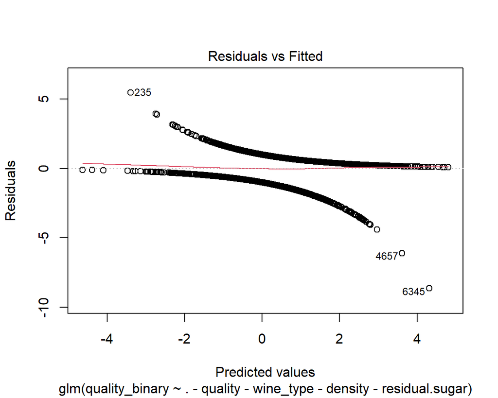

### Base Model Result

First I converted the quality data to a binary data. I classified wine that is 5 and lower to be classified as poor wine and wine that is higher than 5 to be classified as good wine.

The Model had some evidence of co linearity earlier so I got the VIF scores for each variable.

The VIF score or Variance Inflation Factor is a measure that quantifies how much the variance of an estimated regression coefficient increases if your predictors are correlated. If there is no correlation among the predictors, the VIFs will be 1.

A VIF above 5 indicates that that variable has colinearity.

Therefore wine_type, density, and residual sugar were removed for colinearity. Also,there seems to be a horizontal pattern in the predicted values against the residuals plot.

### Reduced Model Results

Accuracy : 0.7378  
95% CI : (0.7177, 0.7572) No Information Rate : 0.6429  
Positive Prediction Value : 0.6067  
Negative Prediction Value : 0.8429

As you can see the accuracy of the model is 73.78% which id better than the no information rate. Also, this model seems to do very well when predicting high quality wine but struggles when predicting the lower quality wine. I would say this model is better than the linear model because it passes the assumptions with the error terms. Also, the SSE of the LASSO model was 1074.765 and the Logistic SSE was 808.478.